# Artificial Intelligence Nanodegree

## Convolutional Neural Networks

## Project: Write an Algorithm for a Dog Identification App

In this notebook, some template code has already been provided for you, and you will need to implement additional functionality to successfully complete this project. You will not need to modify the included code beyond what is requested. Sections that begin with **'(IMPLEMENTATION)'** in the header indicate that the following block of code will require additional functionality which you must provide. Instructions will be provided for each section, and the specifics of the implementation are marked in the code block with a 'TODO' statement. Please be sure to read the instructions carefully!

In addition to implementing code, there will be questions that you must answer which relate to the project and your implementation. Each section where you will answer a question is preceded by a **'Question X'** header. Carefully read each question and provide thorough answers in the following text boxes that begin with **'Answer:'**. Your project submission will be evaluated based on your answers to each of the questions and the implementation you provide.

> **Note:** Code and Markdown cells can be executed using the **Shift + Enter** keyboard shortcut. Markdown cells can be edited by double-clicking the cell to enter edit mode.

The rubric contains *optional* "Stand Out Suggestions" for enhancing the project beyond the minimum requirements. If you decide to pursue the "Stand Out Suggestions", you should include the code in this IPython notebook.

### Why We're Here

In this notebook, you will make the first steps towards developing an algorithm that could be used as part of a mobile or web app. At the end of this project, your code will accept any user-supplied image as input. If a dog is detected in the image, it will provide an estimate of the dog's breed. If a human is detected, it will provide an estimate of the dog breed that is most resembling. The image below displays potential sample output of your finished project (... but we expect that each student's algorithm will behave differently!).

[figure not shown]

In this real-world setting, you will need to piece together a series of models to perform different tasks; for instance, the algorithm that detects humans in an image will be different from the CNN that infers dog breed. There are many points of possible failure, and no perfect algorithm exists. Your imperfect solution will nonetheless create a fun user experience!

### The Road Ahead

We break the notebook into separate steps. Feel free to use the links below to navigate the notebook.

- Step 0: Import Datasets
- Step 1: Detect Humans
- Step 2: Detect Dogs
- Step 3: Create a CNN to Classify Dog Breeds (from Scratch)
- Step 4: Use a CNN to Classify Dog Breeds (using Transfer Learning)
- Step 5: Create a CNN to Classify Dog Breeds (using Transfer Learning)
- Step 6: Write your Algorithm
- Step 7: Test Your Algorithm

## Step 0: Import Datasets

### Import Dog Dataset

In the code cell below, we import a dataset of dog images. We populate a few variables through the use of the `load_files` function from the scikit-learn library:

- `train_files`, `valid_files`, `test_files` - numpy arrays containing file paths to images
- `train_targets`, `valid_targets`, `test_targets` - numpy arrays containing onehot-encoded classification labels
- `dog_names` - list of string-valued dog breed names for translating labels

```python
from sklearn.datasets import load_files
from keras.utils import np_utils
import numpy as np
from glob import glob

# define function to load train, test, and validation datasets
def load_dataset(path):
    data = load_files(path)
    dog_files = np.array(data['filenames'])
    dog_targets = np_utils.to_categorical(np.array(data['target']), 133)
    return dog_files, dog_targets

# load train, test, and validation datasets
train_files, train_targets = load_dataset('dogImages/train')
valid_files, valid_targets = load_dataset('dogImages/valid')
test_files, test_targets = load_dataset('dogImages/test')

# load list of dog names
dog_names = [item[20:-1] for item in sorted(glob("dogImages/train/*/"))]

# print statistics about the dataset
print('There are %d total dog categories.' % len(dog_names))
print('There are %s total dog images.\n' % len(np.hstack([train_files, valid_files, test_files])))
print('There are %d training dog images.' % len(train_files))
print('There are %d validation dog images.' % len(valid_files))
print('There are %d test dog images.'% len(test_files))
```

```
There are 133 total dog categories.
There are 8351 total dog images.

There are 6680 training dog images.
There are 835 validation dog images.
There are 836 test dog images.
```

### Import Human Dataset

In the code cell below, we import a dataset of human images, where the file paths are stored in the numpy array `human_files`.

```python
import random
random.seed(8675309)

# load filenames in shuffled human dataset
human_files = np.array(glob("lfw/*/*"))
random.shuffle(human_files)

# print statistics about the dataset
print('There are %d total human images.' % len(human_files))
```

```
There are 13233 total human images.
```

## Step 1: Detect Humans

We use OpenCV's implementation of [Haar feature-based cascade classifiers](http://docs.opencv.org/trunk/d7/d8b/tutorial_py_face_detection.html) to detect human faces in images. OpenCV provides many pre-trained face detectors, stored as XML files on [github](https://github.com/opencv/opencv/tree/master/data/haarcascades). We have downloaded one of these detectors and stored it in the `haarcascades` directory.

In the next code cell, we demonstrate how to use this detector to find human faces in a sample image.

```
Number of faces detected: 1
```

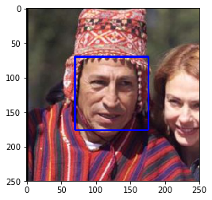

```python
import numpy.core.multiarray
import cv2
import matplotlib.pyplot as plt
%matplotlib inline

# extract pre-trained face detector
face_cascade = cv2.CascadeClassifier('haarcascades/haarcascade_frontalface_alt.xml')

# load color (BGR) image
img = cv2.imread(human_files[10])
# convert BGR image to grayscale
gray = cv2.cvtColor(img, cv2.COLOR_BGR2GRAY)

# find faces in image
faces = face_cascade.detectMultiScale(gray)

# print number of faces detected in the image
print('Number of faces detected:', len(faces))

# get bounding box for each detected face
for (x,y,w,h) in faces:
    # add bounding box to color image
    cv2.rectangle(img,(x,y),(x+w,y+h),(255,0,0),2)

# convert BGR image to RGB for plotting
cv_rgb = cv2.cvtColor(img, cv2.COLOR_BGR2RGB)

# display the image, along with bounding box
plt.imshow(cv_rgb)
plt.show()
```

Before using any of the face detectors, it is standard procedure to convert the images to grayscale. The `detectMultiScale` function executes the classifier stored in `face_cascade` and takes the grayscale image as a parameter.

In the above code, `faces` is a numpy array of detected faces, where each row corresponds to a detected face. Each detected face is a 1D array with four entries that specifies the bounding box of the detected face. The first two entries in the array (extracted in the above code as `x` and `y`) specify the horizontal and vertical positions of the top left corner of the bounding box. The last two entries in the array (extracted here as `w` and `h`) specify the width and height of the box.

### Write a Human Face Detector

We can use this procedure to write a function that returns `True` if a human face is detected in an image and `False` otherwise. This function, aptly named `face_detector`, takes a string-valued file path to an image as input and appears in the code block below.

```python
# returns "True" if face is detected in image stored at img_path
def face_detector(img_path):
    img = cv2.imread(img_path)
    gray = cv2.cvtColor(img, cv2.COLOR_BGR2GRAY)
    faces = face_cascade.detectMultiScale(gray)
    return len(faces) > 0
```

### (IMPLEMENTATION) Assess the Human Face Detector

**Question 1:** Use the code cell below to test the performance of the `face_detector` function.

- What percentage of the first 100 images in `human_files` have a detected human face?
- What percentage of the first 100 images in `dog_files` have a detected human face?

Ideally, we would like 100% of human images with a detected face and 0% of dog images with a detected face. You will see that our algorithm falls short of this goal, but still gives acceptable performance. We extract the file paths for the first 100 images from each of the datasets and store them in the numpy arrays `human_files_short` and `dog_files_short`.

**Answer:**  
Percentage of the first 100 images in human_files have a detected human face: 99  
Percentage of the first 100 images in dog_files have a detected human face: 11

```python
human_files_short = human_files[:100]
dog_files_short = train_files[:100]
# Do NOT modify the code above this line.

## TODO: Test the performance of the face_detector algorithm
## on the images in human_files_short and dog_files_short.

human_detect_rate_h = sum([face_detector(human) for human in human_files_short])*100/len(human_files_short)
human_detect_rate_d = sum([face_detector(dog) for dog in dog_files_short])*100/len(dog_files_short)

print('Percentage of the first 100 images in human_files have a detected human face: %d' % human_detect_rate_h)
print('Percentage of the first 100 images in dog_files have a detected human face: %d' % human_detect_rate_d)
```

```
Percentage of the first 100 images in human_files have a detected human face: 99
Percentage of the first 100 images in dog_files have a detected human face: 11
```

```python
dog_files_short[1]
```

```
'dogImages/train\\057.Dalmatian\\Dalmatian_04054.jpg'
```

**Question 2:** This algorithmic choice necessitates that we communicate to the user that we accept human images only when they provide a clear view of a face (otherwise, we risk having unneccessarily frustrated users!). In your opinion, is this a reasonable expectation to pose on the user? If not, can you think of a way to detect humans in images that does not necessitate an image with a clearly presented face?

**Answer:**

We suggest the face detector from OpenCV as a potential way to detect human images in your algorithm, but you are free to explore other approaches, especially approaches that make use of deep learning :). Please use the code cell below to design and test your own face detection algorithm. If you decide to pursue this *optional* task, report performance on each of the datasets.

**Answer:** Face detector from OpenCV is definitely a potential way to detect human images in this algorithm. Alternatively, we could build a deep convolutional network with labels to detech a Human vs Dog.

## Step 2: Detect Dogs

In this section, we use a pre-trained [ResNet-50](http://ethereon.github.io/netscope/#/gist/db945b393d40bfa26006) model to detect dogs in images. Our first line of code downloads the ResNet-50 model, along with weights that have been trained on [ImageNet](http://www.image-net.org/), a very large, very popular dataset used for image classification and other vision tasks. ImageNet contains over 10 million URLs, each linking to an image containing an object from one of [1000 categories](https://gist.github.com/yrevar/942d3a0ac09ec9e5eb3a). Given an image, this pre-trained ResNet-50 model returns a prediction (derived from the available categories in ImageNet) for the object that is contained in the image.

```python
from keras.applications.resnet50 import ResNet50

# define ResNet50 model
ResNet50_model = ResNet50(weights='imagenet')
```

### Pre-process the Data

When using TensorFlow as backend, Keras CNNs require a 4D array (which we'll also refer to as a 4D tensor) as input, with shape

$$ (\text{nb_samples}, \text{rows}, \text{columns}, \text{channels}), $$

where `nb_samples` corresponds to the total number of images (or samples), and `rows`, `columns`, and `channels` correspond to the number of rows, columns, and channels for each image, respectively.

The `path_to_tensor` function below takes a string-valued file path to a color image as input and returns a 4D tensor suitable for supplying to a Keras CNN. The function first loads the image and resizes it to a square image that is $224 \times 224$ pixels. Next, the image is converted to an array, which is then resized to a 4D tensor. In this case, since we are working with color images, each image has three channels. Likewise, since we are processing a single image (or sample), the returned tensor will always have shape

$$ (1, 224, 224, 3). $$

The `paths_to_tensor` function takes a numpy array of string-valued image paths as input and returns a 4D tensor with shape

$$ (\text{nb_samples}, 224, 224, 3). $$

Here, `nb_samples` is the number of samples, or number of images, in the supplied array of image paths. It is best to think of `nb_samples` as the number of 3D tensors (where each 3D tensor corresponds to a different image) in your dataset!

```python
from keras.preprocessing import image
from tqdm import tqdm

def path_to_tensor(img_path):
    # loads RGB image as PIL.Image.Image type
    img = image.load_img(img_path, target_size=(224, 224))
    # convert PIL.Image.Image type to 3D tensor with shape (224, 224, 3)
    x = image.img_to_array(img)
    # convert 3D tensor to 4D tensor with shape (1, 224, 224, 3) and return 4D tensor
    return np.expand_dims(x, axis=0)

def paths_to_tensor(img_paths):
    list_of_tensors = [path_to_tensor(img_path) for img_path in tqdm(img_paths)]
    return np.vstack(list_of_tensors)
```

### Making Predictions with ResNet-50

Getting the 4D tensor ready for ResNet-50, and for any other pre-trained model in Keras, requires some additional processing. First, the RGB image is converted to BGR by reordering the channels. All pre-trained models have the additional normalization step that the mean pixel (expressed in RGB as $[103.939, 116.779, 123.68]$ and calculated from all pixels in all images in ImageNet) must be subtracted from every pixel in each image. This is implemented in the imported function `preprocess_input`. If you're curious, you can check the code for `preprocess_input` [here](https://github.com/fchollet/keras/blob/master/keras/applications/imagenet_utils.py).

Now that we have a way to format our image for supplying to ResNet-50, we are now ready to use the model to extract the predictions. This is accomplished with the `predict` method, which returns an array whose $i$-th entry is the model's predicted probability that the image belongs to the $i$-th ImageNet category. This is implemented in the `ResNet50_predict_labels` function below.

By taking the argmax of the predicted probability vector, we obtain an integer corresponding to the model's predicted object class, which we can identify with an object category through the use of this [dictionary](https://gist.github.com/yrevar/942d3a0ac09ec9e5eb3a).

```python
from keras.applications.resnet50 import preprocess_input, decode_predictions

def ResNet50_predict_labels(img_path):
    # returns prediction vector for image located at img_path
    img = preprocess_input(path_to_tensor(img_path))
    return np.argmax(ResNet50_model.predict(img))
```

### Write a Dog Detector

While looking at the [dictionary](https://gist.github.com/yrevar/942d3a0ac09ec9e5eb3a), you will notice that the categories corresponding to dogs appear in an uninterrupted sequence and correspond to dictionary keys 151-268, inclusive, to include all categories from `'Chihuahua'` to `'Mexican hairless'`. Thus, in order to check to see if an image is predicted to contain a dog by the pre-trained ResNet-50 model, we need only check if the `ResNet50_predict_labels` function above returns a value between 151 and 268 (inclusive).

We use these ideas to complete the `dog_detector` function below, which returns `True` if a dog is detected in an image (and `False` if not).

```python
### returns "True" if a dog is detected in the image stored at img_path
def dog_detector(img_path):
    prediction = ResNet50_predict_labels(img_path)
    return ((prediction <= 268) & (prediction >= 151))
```

```python
dog_detector(dog_files_short[1])
```

```
True
```

### (IMPLEMENTATION) Assess the Dog Detector

**Question 3:** Use the code cell below to test the performance of your `dog_detector` function.

- What percentage of the images in `human_files_short` have a detected dog?
- What percentage of the images in `dog_files_short` have a detected dog?

**Answer:**

Percentage of the first 100 images in human_files have a detected a dog: 1  
Percentage of the first 100 images in dog_files have a detected a dog: 100

```python
### TODO: Test the performance of the dog_detector function
### on the images in human_files_short and dog_files_short.

dog_detect_rate_h = sum([dog_detector(human) for human in human_files_short])*100/len(human_files_short)
dog_detect_rate_d = sum([dog_detector(dog) for dog in dog_files_short])*100/len(dog_files_short)

print('Percentage of the first 100 images in human_files have a detected a dog: %d' % dog_detect_rate_h)
print('Percentage of the first 100 images in dog_files have a detected a dog: %d' % dog_detect_rate_d)
```

```
Percentage of the first 100 images in human_files have a detected a dog: 1
Percentage of the first 100 images in dog_files have a detected a dog: 100
```

## Step 3: Create a CNN to Classify Dog Breeds (from Scratch)

Now that we have functions for detecting humans and dogs in images, we need a way to predict breed from images. In this step, you will create a CNN that classifies dog breeds. You must create your CNN *from scratch* (so, you can't use transfer learning *yet*!), and you must attain a test accuracy of at least 1%. In Step 5 of this notebook, you will have the opportunity to use transfer learning to create a CNN that attains greatly improved accuracy.

Be careful with adding too many trainable layers! More parameters means longer training, which means you are more likely to need a GPU to accelerate the training process. Thankfully, Keras provides a handy estimate of the time that each epoch is likely to take; you can extrapolate this estimate to figure out how long it will take for your algorithm to train.

We mention that the task of assigning breed to dogs from images is considered exceptionally challenging. To see why, consider that *even a human* would have great difficulty in distinguishing between a Brittany and a Welsh Springer Spaniel.

| Brittany | Welsh Springer Spaniel |
| --- | --- |

It is not difficult to find other dog breed pairs with minimal inter-class variation (for instance, Curly-Coated Retrievers and American Water Spaniels).

| Curly-Coated Retriever | American Water Spaniel |
| --- | --- |

Likewise, recall that labradors come in yellow, chocolate, and black. Your vision-based algorithm will have to conquer this high intra-class variation to determine how to classify all of these different shades as the same breed.

| Yellow Labrador | Chocolate Labrador | Black Labrador |
| --- | --- | --- |

We also mention that random chance presents an exceptionally low bar: setting aside the fact that the classes are slightly imabalanced, a random guess will provide a correct answer roughly 1 in 133 times, which corresponds to an accuracy of less than 1%.

Remember that the practice is far ahead of the theory in deep learning. Experiment with many different architectures, and trust your intuition. And, of course, have fun!

### Pre-process the Data

We rescale the images by dividing every pixel in every image by 255.

```python
from PIL import ImageFile
ImageFile.LOAD_TRUNCATED_IMAGES = True

# pre-process the data for Keras
train_tensors = paths_to_tensor(train_files).astype('float32')/255
valid_tensors = paths_to_tensor(valid_files).astype('float32')/255
test_tensors = paths_to_tensor(test_files).astype('float32')/255
```

### (IMPLEMENTATION) Model Architecture

Create a CNN to classify dog breed. At the end of your code cell block, summarize the layers of your model by executing the line:

```
    model.summary()
```

We have imported some Python modules to get you started, but feel free to import as many modules as you need. If you end up getting stuck, here's a hint that specifies a model that trains relatively fast on CPU and attains >1% test accuracy in 5 epochs:

[figure not shown]

**Question 4:** Outline the steps you took to get to your final CNN architecture and your reasoning at each step. If you chose to use the hinted architecture above, describe why you think that CNN architecture should work well for the image classification task.

**Answer:** **Architecure Details**

This architecture gave a training accuracy of ~25%, but test accuracy was still low. Stacking more convolutions with Gradual increase in depth with added measures to avoid overfitting would provide some better results.

```python
from keras.layers import Conv2D, MaxPooling2D, GlobalAveragePooling2D
from keras.layers import Dropout, Flatten, Dense
from keras.models import Sequential
from keras.initializers import TruncatedNormal
from keras.layers.advanced_activations import LeakyReLU, PReLU, ELU
from keras.layers.normalization import BatchNormalization
from keras import regularizers

input_shape = train_tensors.shape[1:]

print(input_shape)
weights_bias = TruncatedNormal(mean=0.0, stddev=0.01, seed=None)
model = Sequential()
activation_fn = 'relu'


### TODO: Define your architecture.
model.add(Conv2D(filters=16, input_shape = input_shape,kernel_size=(3,3), padding='same', activation=activation_fn,
                 kernel_initializer= 'truncated_normal'))
#model.add(BatchNormalization(axis=1))
#model.add(LeakyReLU(alpha=.01))
model.add(MaxPooling2D(pool_size=(2,2)))
model.add(Dropout(0.2))


model.add(Conv2D(filters=64, kernel_size=(3,3), padding='same', activation=activation_fn,
                 kernel_initializer= 'truncated_normal'))
model.add(BatchNormalization())
#model.add(LeakyReLU(alpha=.01))
model.add(MaxPooling2D(pool_size=(2,2)))
model.add(Dropout(0.2))

model.add(Conv2D(filters=128, kernel_size=(3,3), padding='same', activation=activation_fn,
                 kernel_initializer= 'truncated_normal'))
model.add(BatchNormalization())
#model.add(LeakyReLU(alpha=.01))
model.add(GlobalAveragePooling2D())
model.add(Dropout(0.2))



model.add(Dense(512, activation=activation_fn))
model.add(BatchNormalization())
#model.add(LeakyReLU(alpha=.01))
model.add(Dropout(0.2))

model.add(Dense(1024, activation=activation_fn))
model.add(BatchNormalization())
#model.add(LeakyReLU(alpha=.01))
model.add(Dropout(0.2))

model.add(Dense(133, activation='softmax'))


model.summary()
```

```
(224, 224, 3)
_________________________________________________________________
Layer (type)                 Output Shape              Param #
=================================================================
conv2d_50 (Conv2D)           (None, 224, 224, 16)      448
_________________________________________________________________
max_pooling2d_35 (MaxPooling (None, 112, 112, 16)      0
_________________________________________________________________
dropout_91 (Dropout)         (None, 112, 112, 16)      0
_________________________________________________________________
conv2d_51 (Conv2D)           (None, 112, 112, 64)      9280
_________________________________________________________________
batch_normalization_75 (Batc (None, 112, 112, 64)      256
_________________________________________________________________
max_pooling2d_36 (MaxPooling (None, 56, 56, 64)        0
_________________________________________________________________
dropout_92 (Dropout)         (None, 56, 56, 64)        0
_________________________________________________________________
conv2d_52 (Conv2D)           (None, 56, 56, 128)       73856
_________________________________________________________________
batch_normalization_76 (Batc (None, 56, 56, 128)       512
_________________________________________________________________
global_average_pooling2d_21  (None, 128)               0
_________________________________________________________________
dropout_93 (Dropout)         (None, 128)               0
_________________________________________________________________
dense_62 (Dense)             (None, 512)               66048
_________________________________________________________________
batch_normalization_77 (Batc (None, 512)               2048
_________________________________________________________________
dropout_94 (Dropout)         (None, 512)               0
_________________________________________________________________
dense_63 (Dense)             (None, 1024)              525312
_________________________________________________________________
batch_normalization_78 (Batc (None, 1024)              4096
_________________________________________________________________
dropout_95 (Dropout)         (None, 1024)              0
_________________________________________________________________
dense_64 (Dense)             (None, 133)               136325
=================================================================
Total params: 818,181
Trainable params: 814,725
Non-trainable params: 3,456
_________________________________________________________________
```

### Compile the Model

```python
from keras import optimizers

epochs = 50
batch_size = 20
learning_rate  = 0.001
momentum = 0.9
decay_rate = learning_rate / epochs
sgd_opt = optimizers.SGD(lr = learning_rate, momentum = momentum, decay = decay_rate, nesterov=False)
#adam_opt = optimizers.Adam(lr=0.001, beta_1=0.9, beta_2=0.999, epsilon=1e-08, decay=0.0)
model.compile(optimizer=sgd_opt, loss='categorical_crossentropy', metrics=['accuracy'])
```

### (IMPLEMENTATION) Train the Model

Train your model in the code cell below. Use model checkpointing to save the model that attains the best validation loss.

You are welcome to [augment the training data](https://blog.keras.io/building-powerful-image-classification-models-using-very-little-data.html), but this is not a requirement.

### Augmenting the training Data

```python
from keras.preprocessing.image import ImageDataGenerator

def data_augmenter(train_tensors, valid_tensors):

    # create and configure augmented image generator
    datagen_train = ImageDataGenerator(
        width_shift_range=0.1,  # randomly shift images horizontally (10% of total width)
        height_shift_range=0.1,  # randomly shift images vertically (10% of total height)
        horizontal_flip=True) # randomly flip images horizontally

    # create and configure augmented image generator
    datagen_valid = ImageDataGenerator(
        width_shift_range=0.1,  # randomly shift images horizontally (10% of total width)
        height_shift_range=0.1,  # randomly shift images vertically (10% of total height)
        horizontal_flip=True) # randomly flip images horizontally

    # fit augmented image generator on data
    datagen_train.fit(train_tensors)
    datagen_valid.fit(valid_tensors)

    return datagen_train,datagen_valid
```

### Train the Model

```python
from keras.callbacks import ModelCheckpoint
datagen_train, datagen_valid = data_augmenter(train_tensors,valid_tensors )

### Do NOT modify the code below this line.

checkpointer = ModelCheckpoint(filepath='saved_models/weights.best.from_scratch.hdf5',
                               save_best_only=True)

#model.fit(train_tensors, train_targets, validation_data=(valid_tensors, valid_targets),
#          epochs=epochs, batch_size=20, callbacks=[checkpointer])


model.fit_generator(datagen_train.flow(train_tensors, train_targets, batch_size=batch_size),
                    steps_per_epoch=train_tensors.shape[0] // batch_size,
                    epochs=epochs, verbose=2, callbacks=[checkpointer],
                    validation_data=datagen_valid.flow(valid_tensors, valid_targets, batch_size=batch_size),
                    validation_steps=valid_tensors.shape[0] // batch_size)
```

```
55s - loss: 4.9209 - acc: 0.0243 - val_loss: 5.0240 - val_acc: 0.0244
52s - loss: 4.8815 - acc: 0.0295 - val_loss: 5.1811 - val_acc: 0.0207
52s - loss: 4.8348 - acc: 0.0287 - val_loss: 5.6229 - val_acc: 0.0207
51s - loss: 4.7736 - acc: 0.0359 - val_loss: 5.8526 - val_acc: 0.0134
52s - loss: 4.7376 - acc: 0.0347 - val_loss: 5.2889 - val_acc: 0.0134
51s - loss: 4.7048 - acc: 0.0386 - val_loss: 5.5596 - val_acc: 0.0195
51s - loss: 4.6563 - acc: 0.0397 - val_loss: 5.5713 - val_acc: 0.0220
51s - loss: 4.6590 - acc: 0.0419 - val_loss: 8.0791 - val_acc: 0.0110
53s - loss: 4.5958 - acc: 0.0454 - val_loss: 5.7664 - val_acc: 0.0207
51s - loss: 4.5216 - acc: 0.0501 - val_loss: 5.4776 - val_acc: 0.0390
52s - loss: 4.4774 - acc: 0.0537 - val_loss: 5.8431 - val_acc: 0.0232
52s - loss: 4.4551 - acc: 0.0545 - val_loss: 6.6037 - val_acc: 0.0171
52s - loss: 4.4357 - acc: 0.0603 - val_loss: 5.9465 - val_acc: 0.0317
52s - loss: 4.3748 - acc: 0.0653 - val_loss: 6.8210 - val_acc: 0.0268
52s - loss: 4.3252 - acc: 0.0663 - val_loss: 7.7911 - val_acc: 0.0220
52s - loss: 4.2654 - acc: 0.0719 - val_loss: 5.7180 - val_acc: 0.0415
52s - loss: 4.2562 - acc: 0.0753 - val_loss: 7.9011 - val_acc: 0.0244
52s - loss: 4.2086 - acc: 0.0769 - val_loss: 4.8385 - val_acc: 0.0537
52s - loss: 4.1757 - acc: 0.0819 - val_loss: 8.8401 - val_acc: 0.0305
51s - loss: 4.1334 - acc: 0.0853 - val_loss: 6.0361 - val_acc: 0.0354
52s - loss: 4.0617 - acc: 0.0916 - val_loss: 6.7022 - val_acc: 0.0415
52s - loss: 4.0323 - acc: 0.0976 - val_loss: 6.0147 - val_acc: 0.0439
52s - loss: 3.9645 - acc: 0.0993 - val_loss: 6.1420 - val_acc: 0.0488
52s - loss: 3.9391 - acc: 0.1055 - val_loss: 6.2141 - val_acc: 0.0439
52s - loss: 3.8908 - acc: 0.1096 - val_loss: 6.5263 - val_acc: 0.0415
52s - loss: 3.8366 - acc: 0.1199 - val_loss: 7.8212 - val_acc: 0.0268
52s - loss: 3.8025 - acc: 0.1180 - val_loss: 6.3074 - val_acc: 0.0524
52s - loss: 3.7443 - acc: 0.1296 - val_loss: 6.7774 - val_acc: 0.0366
52s - loss: 3.7158 - acc: 0.1262 - val_loss: 9.8903 - val_acc: 0.0232
53s - loss: 3.6775 - acc: 0.1316 - val_loss: 7.7517 - val_acc: 0.0366
52s - loss: 3.6334 - acc: 0.1430 - val_loss: 6.2822 - val_acc: 0.0488
52s - loss: 3.5861 - acc: 0.1490 - val_loss: 6.0855 - val_acc: 0.0549
52s - loss: 3.5443 - acc: 0.1515 - val_loss: 7.5671 - val_acc: 0.0305
52s - loss: 3.4985 - acc: 0.1597 - val_loss: 10.8987 - val_acc: 0.0256
52s - loss: 3.4744 - acc: 0.1639 - val_loss: 8.7539 - val_acc: 0.0329
52s - loss: 3.4418 - acc: 0.1665 - val_loss: 8.7990 - val_acc: 0.0390
52s - loss: 3.3927 - acc: 0.1760 - val_loss: 6.2643 - val_acc: 0.0549
52s - loss: 3.3556 - acc: 0.1804 - val_loss: 6.7795 - val_acc: 0.0524
52s - loss: 3.3231 - acc: 0.1859 - val_loss: 7.5652 - val_acc: 0.0610
53s - loss: 3.2997 - acc: 0.1847 - val_loss: 9.7433 - val_acc: 0.0293
53s - loss: 3.2520 - acc: 0.2010 - val_loss: 7.0767 - val_acc: 0.0476
53s - loss: 3.2287 - acc: 0.2084 - val_loss: 6.8168 - val_acc: 0.0500
53s - loss: 3.1963 - acc: 0.2081 - val_loss: 5.4289 - val_acc: 0.0890
52s - loss: 3.1449 - acc: 0.2187 - val_loss: 6.0714 - val_acc: 0.0707
52s - loss: 3.1145 - acc: 0.2145 - val_loss: 6.4731 - val_acc: 0.0561
52s - loss: 3.0963 - acc: 0.2195 - val_loss: 8.0090 - val_acc: 0.0427
51s - loss: 3.0529 - acc: 0.2350 - val_loss: 7.6887 - val_acc: 0.0549
50s - loss: 3.0263 - acc: 0.2382 - val_loss: 7.8782 - val_acc: 0.0451
50s - loss: 2.9983 - acc: 0.2428 - val_loss: 6.5314 - val_acc: 0.0659
50s - loss: 2.9762 - acc: 0.2461 - val_loss: 9.5412 - val_acc: 0.0366
```

```
<keras.callbacks.History at 0x18cc8ce6390>
```

### Load the Model with the Best Validation Loss

```python
model.load_weights('saved_models/weights.best.from_scratch.hdf5')
```

### Test the Model

Try out your model on the test dataset of dog images. Ensure that your test accuracy is greater than 1%.

```python
# get index of predicted dog breed for each image in test set
dog_breed_predictions = [np.argmax(model.predict(np.expand_dims(tensor, axis=0))) for tensor in test_tensors]

# report test accuracy
test_accuracy = 100*np.sum(np.array(dog_breed_predictions)==np.argmax(test_targets, axis=1))/len(dog_breed_predictions)
print('Test accuracy: %.4f%%' % test_accuracy)
```

```
Test accuracy: 4.9043%
```

## Step 4: Use a CNN to Classify Dog Breeds

To reduce training time without sacrificing accuracy, we show you how to train a CNN using transfer learning. In the following step, you will get a chance to use transfer learning to train your own CNN.

### Obtain Bottleneck Features

```python
bottleneck_features = np.load('bottleneck_features/DogVGG16Data.npz')
train_VGG16 = bottleneck_features['train']
valid_VGG16 = bottleneck_features['valid']
test_VGG16 = bottleneck_features['test']
train_VGG16.shape
```

```
(6680, 7, 7, 512)
```

### Model Architecture

The model uses the the pre-trained VGG-16 model as a fixed feature extractor, where the last convolutional output of VGG-16 is fed as input to our model. We only add a global average pooling layer and a fully connected layer, where the latter contains one node for each dog category and is equipped with a softmax.

```python
VGG16_model = Sequential()
VGG16_model.add(GlobalAveragePooling2D(input_shape=train_VGG16.shape[1:]))
VGG16_model.add(Dense(133, activation='softmax'))

VGG16_model.summary()
```

```
_________________________________________________________________
Layer (type)                 Output Shape              Param #
=================================================================
global_average_pooling2d_17  (None, 512)               0
_________________________________________________________________
dense_49 (Dense)             (None, 133)               68229
=================================================================
Total params: 68,229
Trainable params: 68,229
Non-trainable params: 0
_________________________________________________________________
```

### Compile the Model

```python
VGG16_model.compile(loss='categorical_crossentropy', optimizer='rmsprop', metrics=['accuracy'])
```

### Train the Model

```python
checkpointer = ModelCheckpoint(filepath='saved_models/weights.best.VGG16.hdf5',
                               verbose=1, save_best_only=True)

VGG16_model.fit(train_VGG16, train_targets,
          validation_data=(valid_VGG16, valid_targets),
          epochs=20, batch_size=20, callbacks=[checkpointer], verbose=2)
```

```
Train on 6680 samples, validate on 835 samples
Epoch 00000: val_loss improved from inf to 10.38681, saving model to saved_models/weights.best.VGG16.hdf5
2s - loss: 12.1615 - acc: 0.1329 - val_loss: 10.3868 - val_acc: 0.2275
Epoch 00001: val_loss improved from 10.38681 to 9.48942, saving model to saved_models/weights.best.VGG16.hdf5
1s - loss: 9.6135 - acc: 0.3061 - val_loss: 9.4894 - val_acc: 0.3066
Epoch 00002: val_loss improved from 9.48942 to 8.89713, saving model to saved_models/weights.best.VGG16.hdf5
1s - loss: 8.9479 - acc: 0.3744 - val_loss: 8.8971 - val_acc: 0.3629
Epoch 00003: val_loss improved from 8.89713 to 8.71549, saving model to saved_models/weights.best.VGG16.hdf5
1s - loss: 8.5432 - acc: 0.4097 - val_loss: 8.7155 - val_acc: 0.3856
Epoch 00004: val_loss improved from 8.71549 to 8.54146, saving model to saved_models/weights.best.VGG16.hdf5
1s - loss: 8.2903 - acc: 0.4394 - val_loss: 8.5415 - val_acc: 0.3964
Epoch 00005: val_loss improved from 8.54146 to 8.48530, saving model to saved_models/weights.best.VGG16.hdf5
1s - loss: 8.1545 - acc: 0.4581 - val_loss: 8.4853 - val_acc: 0.3904
Epoch 00006: val_loss improved from 8.48530 to 8.43667, saving model to saved_models/weights.best.VGG16.hdf5
1s - loss: 8.0240 - acc: 0.4707 - val_loss: 8.4367 - val_acc: 0.3964
Epoch 00007: val_loss did not improve
1s - loss: 7.9475 - acc: 0.4814 - val_loss: 8.4410 - val_acc: 0.4120
Epoch 00008: val_loss improved from 8.43667 to 8.33344, saving model to saved_models/weights.best.VGG16.hdf5
1s - loss: 7.8388 - acc: 0.4910 - val_loss: 8.3334 - val_acc: 0.4072
Epoch 00009: val_loss improved from 8.33344 to 8.30732, saving model to saved_models/weights.best.VGG16.hdf5
1s - loss: 7.7768 - acc: 0.4987 - val_loss: 8.3073 - val_acc: 0.4012
Epoch 00010: val_loss improved from 8.30732 to 8.26915, saving model to saved_models/weights.best.VGG16.hdf5
1s - loss: 7.7247 - acc: 0.5058 - val_loss: 8.2692 - val_acc: 0.4084
Epoch 00011: val_loss improved from 8.26915 to 8.22482, saving model to saved_models/weights.best.VGG16.hdf5
1s - loss: 7.6605 - acc: 0.5111 - val_loss: 8.2248 - val_acc: 0.4096
Epoch 00012: val_loss improved from 8.22482 to 8.15376, saving model to saved_models/weights.best.VGG16.hdf5
1s - loss: 7.5853 - acc: 0.5150 - val_loss: 8.1538 - val_acc: 0.4228
Epoch 00013: val_loss improved from 8.15376 to 8.10688, saving model to saved_models/weights.best.VGG16.hdf5
1s - loss: 7.5019 - acc: 0.5202 - val_loss: 8.1069 - val_acc: 0.4108
Epoch 00014: val_loss improved from 8.10688 to 7.96262, saving model to saved_models/weights.best.VGG16.hdf5
1s - loss: 7.2872 - acc: 0.5278 - val_loss: 7.9626 - val_acc: 0.4251
Epoch 00015: val_loss improved from 7.96262 to 7.89837, saving model to saved_models/weights.best.VGG16.hdf5
1s - loss: 7.1613 - acc: 0.5419 - val_loss: 7.8984 - val_acc: 0.4204
Epoch 00016: val_loss improved from 7.89837 to 7.64664, saving model to saved_models/weights.best.VGG16.hdf5
1s - loss: 7.0173 - acc: 0.5481 - val_loss: 7.6466 - val_acc: 0.4383
Epoch 00017: val_loss improved from 7.64664 to 7.64197, saving model to saved_models/weights.best.VGG16.hdf5
1s - loss: 6.8825 - acc: 0.5620 - val_loss: 7.6420 - val_acc: 0.4479
Epoch 00018: val_loss did not improve
1s - loss: 6.8607 - acc: 0.5665 - val_loss: 7.6730 - val_acc: 0.4563
Epoch 00019: val_loss did not improve
1s - loss: 6.8534 - acc: 0.5681 - val_loss: 7.6481 - val_acc: 0.4491
```

```
<keras.callbacks.History at 0x18cc8e2cda0>
```

### Load the Model with the Best Validation Loss

```python
VGG16_model.load_weights('saved_models/weights.best.VGG16.hdf5')
```

### Test the Model

Now, we can use the CNN to test how well it identifies breed within our test dataset of dog images. We print the test accuracy below.

```python
# get index of predicted dog breed for each image in test set
VGG16_predictions = [np.argmax(VGG16_model.predict(np.expand_dims(feature, axis=0))) for feature in test_VGG16]

# report test accuracy
test_accuracy = 100*np.sum(np.array(VGG16_predictions)==np.argmax(test_targets, axis=1))/len(VGG16_predictions)
print('Test accuracy: %.4f%%' % test_accuracy)
```

```
Test accuracy: 44.2584%
```

### Predict Dog Breed with the Model

```python
from extract_bottleneck_features import *

def VGG16_predict_breed(img_path):
    # extract bottleneck features
    bottleneck_feature = extract_VGG16(path_to_tensor(img_path))
    # obtain predicted vector
    predicted_vector = VGG16_model.predict(bottleneck_feature)
    # return dog breed that is predicted by the model
    return dog_names[np.argmax(predicted_vector)]
```

```python
VGG16_predict_breed('dogImages/train\\020.Belgian_malinois\\Belgian_malinois_01402.jpg')
```

```
'Dachshund'
```

## Step 5: Create a CNN to Classify Dog Breeds (using Transfer Learning)

You will now use transfer learning to create a CNN that can identify dog breed from images. Your CNN must attain at least 60% accuracy on the test set.

In Step 4, we used transfer learning to create a CNN using VGG-16 bottleneck features. In this section, you must use the bottleneck features from a different pre-trained model. To make things easier for you, we have pre-computed the features for all of the networks that are currently available in Keras:

- [VGG-19](https://s3-us-west-1.amazonaws.com/udacity-aind/dog-project/DogVGG19Data.npz) bottleneck features
- [ResNet-50](https://s3-us-west-1.amazonaws.com/udacity-aind/dog-project/DogResnet50Data.npz) bottleneck features
- [Inception](https://s3-us-west-1.amazonaws.com/udacity-aind/dog-project/DogInceptionV3Data.npz) bottleneck features
- [Xception](https://s3-us-west-1.amazonaws.com/udacity-aind/dog-project/DogXceptionData.npz) bottleneck features

The files are encoded as such:

```
Dog{network}Data.npz
```

where `{network}`, in the above filename, can be one of `VGG19`, `Resnet50`, `InceptionV3`, or `Xception`. Pick one of the above architectures, download the corresponding bottleneck features, and store the downloaded file in the `bottleneck_features/` folder in the repository.

### (IMPLEMENTATION) Obtain Bottleneck Features

In the code block below, extract the bottleneck features corresponding to the train, test, and validation sets by running the following:

```
bottleneck_features = np.load('bottleneck_features/Dog{network}Data.npz')
train_{network} = bottleneck_features['train']
valid_{network} = bottleneck_features['valid']
test_{network} = bottleneck_features['test']
```

### Choosing XCEPTION Architecture

```python
# Based on the architecture, download the appropriate pre trained model (preTrainModel) to extract the
# bottleneck features. Bottleneck features will be later be used to predict the dog breed


architecture_type = 'XCEPTION'  # Choose values from VGG16, VGG19, RESNET, INCEPTION, XCEPTION to choose other architectures

if architecture_type == 'VGG16':
    architecture_path = 'bottleneck_features/DogVGG16Data.npz'
    from keras.applications.vgg16 import VGG16 as preTrainModel, preprocess_input
elif architecture_type == 'VGG19':
    architecture_path = 'bottleneck_features/DogVGG19Data.npz'
    from keras.applications.vgg19 import VGG19 as preTrainModel, preprocess_input
elif architecture_type == 'RESNET':
    architecture_path = 'bottleneck_features/DogResnet50Data.npz'
    from keras.applications.resnet50 import ResNet50 as preTrainModel, preprocess_input
elif architecture_type == 'INCEPTION':
    architecture_path = 'bottleneck_features/DogInceptionV3Data.npz'
    from keras.applications.inception_v3 import InceptionV3 as preTrainModel, preprocess_input
elif architecture_type == 'XCEPTION':
    architecture_path = 'bottleneck_features/DogXceptionData.npz'
    from keras.applications.xception import Xception  as preTrainModel, preprocess_input
```

```python
### TODO: Obtain bottleneck features from another pre-trained CNN.

print(architecture_path)
bottleneck_features = np.load(architecture_path)
train_bottleneck = bottleneck_features['train']
valid_bottleneck = bottleneck_features['valid']
test_bottleneck = bottleneck_features['test']

print(train_bottleneck.shape)
```

```
bottleneck_features/DogXceptionData.npz
(6680, 7, 7, 2048)
```

### (IMPLEMENTATION) Model Architecture

Create a CNN to classify dog breed. At the end of your code cell block, summarize the layers of your model by executing the line:

```
    <your model's name>.summary()
```

**Question 5:** Outline the steps you took to get to your final CNN architecture and your reasoning at each step. Describe why you think the architecture is suitable for the current problem.

**Answer:**

We chose Xception architecture to do Transfer learning for the following reasons:

1. It outperformed V3 while classifying images on ImageNet dataset.
2. Showed a great gain while classifying Google' own JFT dataset with over 350 million high-resolution images annotated with labels from a set of 17,000 classes.
3. Depthwise seperable convolution reduced the number of parameters and computation used in convolutional operations while increasing representational efficiency. They are easy to use as regular convolution layers.

Xception architecture was able to classify 118 dog breeds (amongst the total of 1000 other class labels) with top-5 accuracy of 94.5%. Since our problem deals with detecting a dog breed given any user supplied input, choosing an architecture which does the best in classifying images is a suitable solution, and **Xception** is the one in this case.

**IMPLEMENTATION**:

1. On top of bottleneck features, Connect 3 dense fully connected layers with 4096, 2048 and 1024 nodes respectively.
2. Batch Normalization for better results.
3. Each layer activated by Exponential Linear Unit (ELU) non linearity.
4. Drop out regularization with drop out rate = 30% to avoid overfitting.
5. A final fully connected layer with 133 class outputs using a softmax activation function.
6. Stochastic Gradient Descent Optimization.

### (IMPLEMENTATION) Compile the Model

```python
activation_fn =None
arch_model = Sequential()


arch_model.add(GlobalAveragePooling2D(input_shape=train_bottleneck.shape[1:]))

arch_model.add(Dense(4096, activation=activation_fn))
arch_model.add(BatchNormalization())
#arch_model.add(LeakyReLU(alpha=.01))
arch_model.add(ELU())
arch_model.add(Dropout(0.3))

arch_model.add(Dense(2048, activation=activation_fn))
arch_model.add(BatchNormalization())
#arch_model.add(LeakyReLU(alpha=.01))
arch_model.add(ELU())
arch_model.add(Dropout(0.3))

arch_model.add(Dense(1024, activation=activation_fn))
arch_model.add(BatchNormalization())
#arch_model.add(LeakyReLU(alpha=.01))
arch_model.add(ELU())
arch_model.add(Dropout(0.3))

arch_model.add(Dense(133, activation='softmax'))

arch_model.summary()
```

```
_________________________________________________________________
Layer (type)                 Output Shape              Param #
=================================================================
global_average_pooling2d_24  (None, 2048)              0
_________________________________________________________________
dense_73 (Dense)             (None, 4096)              8392704
_________________________________________________________________
batch_normalization_85 (Batc (None, 4096)              16384
_________________________________________________________________
elu_7 (ELU)                  (None, 4096)              0
_________________________________________________________________
dropout_102 (Dropout)        (None, 4096)              0
_________________________________________________________________
dense_74 (Dense)             (None, 2048)              8390656
_________________________________________________________________
batch_normalization_86 (Batc (None, 2048)              8192
_________________________________________________________________
elu_8 (ELU)                  (None, 2048)              0
_________________________________________________________________
dropout_103 (Dropout)        (None, 2048)              0
_________________________________________________________________
dense_75 (Dense)             (None, 1024)              2098176
_________________________________________________________________
batch_normalization_87 (Batc (None, 1024)              4096
_________________________________________________________________
elu_9 (ELU)                  (None, 1024)              0
_________________________________________________________________
dropout_104 (Dropout)        (None, 1024)              0
_________________________________________________________________
dense_76 (Dense)             (None, 133)               136325
=================================================================
Total params: 19,046,533
Trainable params: 19,032,197
Non-trainable params: 14,336
_________________________________________________________________
```

### (IMPLEMENTATION) Train the Model

Train your model in the code cell below. Use model checkpointing to save the model that attains the best validation loss.

You are welcome to [augment the training data](https://blog.keras.io/building-powerful-image-classification-models-using-very-little-data.html), but this is not a requirement.

```python
from keras import optimizers
sgd_opt = optimizers.SGD(lr=0.001, momentum=0.0, decay=0.0, nesterov=False)
#adam_opt = optimizers.Adam(lr=0.001, beta_1=0.9, beta_2=0.999, epsilon=1e-08, decay=0.0)
arch_model.compile(loss='categorical_crossentropy', optimizer=sgd_opt, metrics=['accuracy'])
```

```python
print('Training %s Model' % architecture_type)
filepath='saved_models/weights.best.'+ architecture_type + '.hdf5'
checkpointer = ModelCheckpoint(filepath = filepath,
                               verbose = 1, save_best_only=True)

arch_model.fit(train_bottleneck, train_targets,
          validation_data=(valid_bottleneck, valid_targets),
          epochs=30, batch_size=20, callbacks=[checkpointer], verbose=2)
```

```
Training XCEPTION Model
Train on 6680 samples, validate on 835 samples
Epoch 00000: val_loss improved from inf to 1.74466, saving model to saved_models/weights.best.XCEPTION.hdf5
9s - loss: 3.6604 - acc: 0.2491 - val_loss: 1.7447 - val_acc: 0.6910
Epoch 00001: val_loss improved from 1.74466 to 0.89277, saving model to saved_models/weights.best.XCEPTION.hdf5
7s - loss: 1.7041 - acc: 0.6247 - val_loss: 0.8928 - val_acc: 0.7856
Epoch 00002: val_loss improved from 0.89277 to 0.69880, saving model to saved_models/weights.best.XCEPTION.hdf5
7s - loss: 1.1458 - acc: 0.7281 - val_loss: 0.6988 - val_acc: 0.8120
Epoch 00003: val_loss improved from 0.69880 to 0.61773, saving model to saved_models/weights.best.XCEPTION.hdf5
7s - loss: 0.9338 - acc: 0.7665 - val_loss: 0.6177 - val_acc: 0.8192
Epoch 00004: val_loss improved from 0.61773 to 0.56801, saving model to saved_models/weights.best.XCEPTION.hdf5
7s - loss: 0.7855 - acc: 0.8003 - val_loss: 0.5680 - val_acc: 0.8335
Epoch 00005: val_loss improved from 0.56801 to 0.53959, saving model to saved_models/weights.best.XCEPTION.hdf5
7s - loss: 0.7171 - acc: 0.8064 - val_loss: 0.5396 - val_acc: 0.8347
Epoch 00006: val_loss improved from 0.53959 to 0.51725, saving model to saved_models/weights.best.XCEPTION.hdf5
7s - loss: 0.6484 - acc: 0.8213 - val_loss: 0.5173 - val_acc: 0.8431
Epoch 00007: val_loss improved from 0.51725 to 0.50157, saving model to saved_models/weights.best.XCEPTION.hdf5
7s - loss: 0.6049 - acc: 0.8377 - val_loss: 0.5016 - val_acc: 0.8455
Epoch 00008: val_loss improved from 0.50157 to 0.49050, saving model to saved_models/weights.best.XCEPTION.hdf5
7s - loss: 0.5625 - acc: 0.8415 - val_loss: 0.4905 - val_acc: 0.8503
Epoch 00009: val_loss improved from 0.49050 to 0.48353, saving model to saved_models/weights.best.XCEPTION.hdf5
7s - loss: 0.5395 - acc: 0.8493 - val_loss: 0.4835 - val_acc: 0.8419
Epoch 00010: val_loss improved from 0.48353 to 0.47417, saving model to saved_models/weights.best.XCEPTION.hdf5
7s - loss: 0.4945 - acc: 0.8657 - val_loss: 0.4742 - val_acc: 0.8527
Epoch 00011: val_loss improved from 0.47417 to 0.46533, saving model to saved_models/weights.best.XCEPTION.hdf5
7s - loss: 0.4787 - acc: 0.8620 - val_loss: 0.4653 - val_acc: 0.8527
Epoch 00012: val_loss improved from 0.46533 to 0.46188, saving model to saved_models/weights.best.XCEPTION.hdf5
7s - loss: 0.4503 - acc: 0.8713 - val_loss: 0.4619 - val_acc: 0.8503
Epoch 00013: val_loss improved from 0.46188 to 0.45691, saving model to saved_models/weights.best.XCEPTION.hdf5
7s - loss: 0.4380 - acc: 0.8760 - val_loss: 0.4569 - val_acc: 0.8527
Epoch 00014: val_loss improved from 0.45691 to 0.45264, saving model to saved_models/weights.best.XCEPTION.hdf5
7s - loss: 0.4288 - acc: 0.8756 - val_loss: 0.4526 - val_acc: 0.8563
Epoch 00015: val_loss improved from 0.45264 to 0.44896, saving model to saved_models/weights.best.XCEPTION.hdf5
7s - loss: 0.3985 - acc: 0.8841 - val_loss: 0.4490 - val_acc: 0.8551
Epoch 00016: val_loss did not improve
6s - loss: 0.3903 - acc: 0.8855 - val_loss: 0.4500 - val_acc: 0.8575
Epoch 00017: val_loss improved from 0.44896 to 0.44506, saving model to saved_models/weights.best.XCEPTION.hdf5
7s - loss: 0.3801 - acc: 0.8904 - val_loss: 0.4451 - val_acc: 0.8575
Epoch 00018: val_loss did not improve
6s - loss: 0.3593 - acc: 0.8934 - val_loss: 0.4456 - val_acc: 0.8563
Epoch 00019: val_loss improved from 0.44506 to 0.44386, saving model to saved_models/weights.best.XCEPTION.hdf5
7s - loss: 0.3458 - acc: 0.9009 - val_loss: 0.4439 - val_acc: 0.8563
Epoch 00020: val_loss improved from 0.44386 to 0.44205, saving model to saved_models/weights.best.XCEPTION.hdf5
7s - loss: 0.3334 - acc: 0.9039 - val_loss: 0.4421 - val_acc: 0.8563
Epoch 00021: val_loss improved from 0.44205 to 0.43630, saving model to saved_models/weights.best.XCEPTION.hdf5
7s - loss: 0.3384 - acc: 0.8969 - val_loss: 0.4363 - val_acc: 0.8587
Epoch 00022: val_loss did not improve
6s - loss: 0.3252 - acc: 0.9057 - val_loss: 0.4378 - val_acc: 0.8587
Epoch 00023: val_loss improved from 0.43630 to 0.43589, saving model to saved_models/weights.best.XCEPTION.hdf5
7s - loss: 0.3180 - acc: 0.9060 - val_loss: 0.4359 - val_acc: 0.8587
Epoch 00024: val_loss improved from 0.43589 to 0.43368, saving model to saved_models/weights.best.XCEPTION.hdf5
7s - loss: 0.3055 - acc: 0.9139 - val_loss: 0.4337 - val_acc: 0.8611
Epoch 00025: val_loss improved from 0.43368 to 0.43245, saving model to saved_models/weights.best.XCEPTION.hdf5
7s - loss: 0.2979 - acc: 0.9127 - val_loss: 0.4325 - val_acc: 0.8611
Epoch 00026: val_loss did not improve
6s - loss: 0.2781 - acc: 0.9222 - val_loss: 0.4345 - val_acc: 0.8587
Epoch 00027: val_loss did not improve
6s - loss: 0.2706 - acc: 0.9222 - val_loss: 0.4353 - val_acc: 0.8563
Epoch 00028: val_loss did not improve
6s - loss: 0.2715 - acc: 0.9241 - val_loss: 0.4357 - val_acc: 0.8587
Epoch 00029: val_loss improved from 0.43245 to 0.43168, saving model to saved_models/weights.best.XCEPTION.hdf5
7s - loss: 0.2615 - acc: 0.9253 - val_loss: 0.4317 - val_acc: 0.8587
```

```
<keras.callbacks.History at 0x18dc6883eb8>
```

### (IMPLEMENTATION) Load the Model with the Best Validation Loss

```python
### TODO: Load the model weights with the best validation loss.
#arch_model.load_weights('saved_models/weights.best.VGG19.hdf5')
print(filepath)
arch_model.load_weights(filepath)
```

```
saved_models/weights.best.XCEPTION.hdf5
```

### (IMPLEMENTATION) Test the Model

Try out your model on the test dataset of dog images. Ensure that your test accuracy is greater than 60%.

```python
### TODO: Calculate classification accuracy on the test dataset.
arch_predictions = [np.argmax(arch_model.predict(np.expand_dims(feature, axis=0))) for feature in test_bottleneck]

# report test accuracy
test_accuracy = 100*np.sum(np.array(arch_predictions)==np.argmax(test_targets, axis=1))/len(arch_predictions)
print('Test accuracy: %.4f%%' % test_accuracy)
```

```
Test accuracy: 85.6459%
```

### (IMPLEMENTATION) Predict Dog Breed with the Model

Write a function that takes an image path as input and returns the dog breed (`Affenpinscher`, `Afghan_hound`, etc) that is predicted by your model.

Similar to the analogous function in Step 5, your function should have three steps:

1. Extract the bottleneck features corresponding to the chosen CNN model.
2. Supply the bottleneck features as input to the model to return the predicted vector. Note that the argmax of this prediction vector gives the index of the predicted dog breed.
3. Use the `dog_names` array defined in Step 0 of this notebook to return the corresponding breed.

The functions to extract the bottleneck features can be found in `extract_bottleneck_features.py`, and they have been imported in an earlier code cell. To obtain the bottleneck features corresponding to your chosen CNN architecture, you need to use the function

```
extract_{network}
```

where `{network}`, in the above filename, should be one of `VGG19`, `Resnet50`, `InceptionV3`, or `Xception`.

```python
### TODO: Write a function that takes a path to an image as input
### and returns the dog breed that is predicted by the model.

def predict_breed(img_path, extract_network, arch_model):
    # extract bottleneck features

    img = preprocess_input(path_to_tensor(img_path))
    bottleneck_feature = extract_network.predict(img)
    # obtain predicted vector
    predicted_vector = arch_model.predict(bottleneck_feature)
    # return dog breed that is predicted by the model
    return dog_names[np.argmax(predicted_vector)]
```

```python
extract_network = preTrainModel(weights='imagenet',include_top= False)
```

```python
#test_dog_path = 'dogImages/train\\020.Belgian_malinois\\Belgian_malinois_01402.jpg'
test_dog_path = 'dogImages/train\\012.Australian_shepherd\\Australian_shepherd_00814.jpg'
predict_breed(test_dog_path, extract_network , arch_model)
```

```
'Australian_shepherd'
```

## Test on 1st 30 Test Records

```python
test_dogs = [dog_names[idx] for idx in [np.argmax(test_targets[dog]) for dog in range(30)]]
predicted_dogs = [predict_breed(test_dog_path, extract_network, arch_model)
                  for test_dog_path in test_files[:30]]

classified = []
for i in range(len(test_dogs)):
    if test_dogs[i] == predicted_dogs[i]:
        classified.append('Correctly Classified')
    else:
        classified.append('InCorrectly Classified')


import texttable as tt
tab = tt.Texttable()
headings = ['Actual_Breed','Predicted_Breed', 'Classified']
tab.header(headings)

for row in zip(test_dogs,predicted_dogs, classified):
    tab.add_row(row)

s = tab.draw()
print (s)
```

```
+-----------------------+-----------------------+------------------------+
|     Actual_Breed      |    Predicted_Breed    |       Classified       |
+=======================+=======================+========================+
| Dalmatian             | Dalmatian             | Correctly Classified   |
+-----------------------+-----------------------+------------------------+
| Doberman_pinscher     | Doberman_pinscher     | Correctly Classified   |
+-----------------------+-----------------------+------------------------+
| Papillon              | Papillon              | Correctly Classified   |
+-----------------------+-----------------------+------------------------+
| Bedlington_terrier    | Bedlington_terrier    | Correctly Classified   |
+-----------------------+-----------------------+------------------------+
| Flat-coated_retriever | Flat-coated_retriever | Correctly Classified   |
+-----------------------+-----------------------+------------------------+
| Belgian_sheepdog      | Giant_schnauzer       | InCorrectly Classified |
+-----------------------+-----------------------+------------------------+
| Canaan_dog            | Canaan_dog            | Correctly Classified   |
+-----------------------+-----------------------+------------------------+
| Clumber_spaniel       | Clumber_spaniel       | Correctly Classified   |
+-----------------------+-----------------------+------------------------+
| Lakeland_terrier      | Lakeland_terrier      | Correctly Classified   |
+-----------------------+-----------------------+------------------------+
| Chow_chow             | Chow_chow             | Correctly Classified   |
+-----------------------+-----------------------+------------------------+
| Afghan_hound          | Afghan_hound          | Correctly Classified   |
+-----------------------+-----------------------+------------------------+
| Bedlington_terrier    | Bedlington_terrier    | Correctly Classified   |
+-----------------------+-----------------------+------------------------+
| Glen_of_imaal_terrier | Glen_of_imaal_terrier | Correctly Classified   |
+-----------------------+-----------------------+------------------------+
| Yorkshire_terrier     | Yorkshire_terrier     | Correctly Classified   |
+-----------------------+-----------------------+------------------------+
| German_shepherd_dog   | German_shepherd_dog   | Correctly Classified   |
+-----------------------+-----------------------+------------------------+
| Basenji               | Basenji               | Correctly Classified   |
+-----------------------+-----------------------+------------------------+
| Pomeranian            | Pomeranian            | Correctly Classified   |
+-----------------------+-----------------------+------------------------+
| Boston_terrier        | Boston_terrier        | Correctly Classified   |
+-----------------------+-----------------------+------------------------+
| Japanese_chin         | Japanese_chin         | Correctly Classified   |
```

[output cut: 8 more lines]

```
+-----------------------+-----------------------+------------------------+
| Kuvasz                | Labrador_retriever    | InCorrectly Classified |
+-----------------------+-----------------------+------------------------+
| Briard                | Briard                | Correctly Classified   |
+-----------------------+-----------------------+------------------------+
| Portuguese_water_dog  | Poodle                | InCorrectly Classified |
+-----------------------+-----------------------+------------------------+
| Bedlington_terrier    | Bedlington_terrier    | Correctly Classified   |
+-----------------------+-----------------------+------------------------+
| Bedlington_terrier    | Bedlington_terrier    | Correctly Classified   |
+-----------------------+-----------------------+------------------------+
| Keeshond              | Keeshond              | Correctly Classified   |
+-----------------------+-----------------------+------------------------+
| Old_english_sheepdog  | Old_english_sheepdog  | Correctly Classified   |
+-----------------------+-----------------------+------------------------+
```

Table Idea sourced from [stackoverflow](https://stackoverflow.com/questions/39032720/formatting-lists-into-columns-of-a-table-output-python-3)

## Step 6: Write your Algorithm

Write an algorithm that accepts a file path to an image and first determines whether the image contains a human, dog, or neither. Then,

- if a **dog** is detected in the image, return the predicted breed.
- if a **human** is detected in the image, return the resembling dog breed.
- if **neither** is detected in the image, provide output that indicates an error.

You are welcome to write your own functions for detecting humans and dogs in images, but feel free to use the `face_detector` and `dog_detector` functions developed above. You are **required** to use your CNN from Step 5 to predict dog breed.

Some sample output for our algorithm is provided below, but feel free to design your own user experience!

[figure not shown]

### (IMPLEMENTATION) Write your Algorithm

```python
trmodel= preTrainModel(weights='imagenet')
```

```python
### TODO: Write your algorithm.
### Feel free to use as many code cells as needed.
def dog_or_human(img_path):

    # Check if the image is of a human
    dog_detected = dog_detector_new(img_path)
    if dog_detected:
        dog_looks_like =  predict_breed(img_path, extract_network , arch_model)
        img = cv2.imread(img_path)
        plt.imshow(img)
        plt.show()
        print('You passed Image of a DOG and it looks like: %s' %dog_looks_like)
    else:
        human_detected = face_detector(img_path)
        if human_detected:
            print('Human Detected!!!')
            print('Hello Human You Look Like')
            img = cv2.imread(img_path)
            plt.imshow(img)
            plt.show()
            human_looks_like = predict_breed(img_path, extract_network , arch_model)
            print(human_looks_like + '\n')
        else:
            img = cv2.imread(img_path)
            plt.imshow(img)
            plt.show()
            image_looks_like = predict_breed(img_path, extract_network , arch_model)
            print('I see another animal but it looks like: %s' %image_looks_like)

def path_to_tensor_new(img_path):
    # loads RGB image as PIL.Image.Image type
    img = image.load_img(img_path, target_size=(299, 299))
    # convert PIL.Image.Image type to 3D tensor with shape (224, 224, 3)
    x = image.img_to_array(img)
    # convert 3D tensor to 4D tensor with shape (1, 224, 224, 3) and return 4D tensor
    return np.expand_dims(x, axis=0)

def dog_detector_new(img_path):
    img = preprocess_input(path_to_tensor_new(img_path))
    prediction = np.argmax(trmodel.predict(img))

    return ((prediction <= 268) & (prediction >= 151))
```

```
Human Detected!!!
Hello Human You Look Like
```

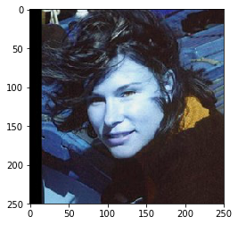

```
Poodle
```

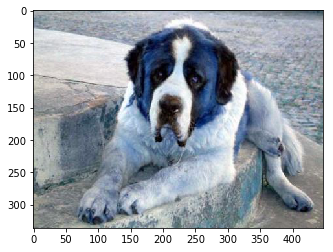

```
You passed Image of a DOG and it looks like: Saint_bernard
```

```python
human_file_path = random.choice(human_files)
dog_or_human(human_file_path)

dog_file_path = random.choice(test_files)
dog_or_human(dog_file_path)
```

## Step 7: Test Your Algorithm

In this section, you will take your new algorithm for a spin! What kind of dog does the algorithm think that **you** look like? If you have a dog, does it predict your dog's breed accurately? If you have a cat, does it mistakenly think that your cat is a dog?

### (IMPLEMENTATION) Test Your Algorithm on Sample Images!

Test your algorithm at least six images on your computer. Feel free to use any images you like. Use at least two human and two dog images.

**Question 6:** Is the output better than you expected :) ? Or worse :( ? Provide at least three possible points of improvement for your algorithm.

**Answer:** Output is as expected.

Ways to improve the algorithm:

1. Adding an another Convolutional layer on top of Xception bottleneck features may improve accuracy.
2. Learning rate decay for every few epochs can better the performance

```python
## TODO: Execute your algorithm from Step 6 on
## at least 6 images on your computer.
## Feel free to use as many code cells as needed.
my_files, my_targets = load_dataset('testmyImages')
```

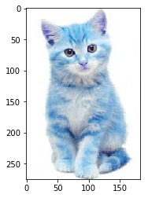

```
I see another animal but it looks like: Brussels_griffon
```

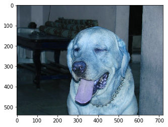

```
You passed Image of a DOG and it looks like: Labrador_retriever
```

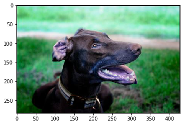

```
You passed Image of a DOG and it looks like: Doberman_pinscher
```

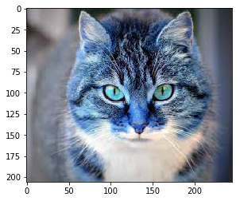

```
I see another animal but it looks like: Cardigan_welsh_corgi
```

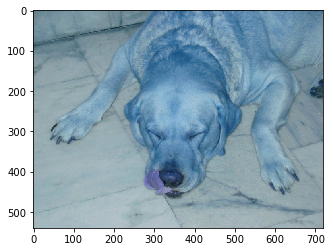

```
You passed Image of a DOG and it looks like: Dogue_de_bordeaux
```

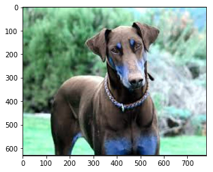

```
You passed Image of a DOG and it looks like: Doberman_pinscher
Human Detected!!!
Hello Human You Look Like
```

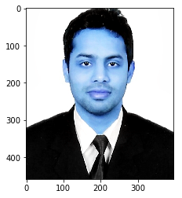

```
Boston_terrier

Human Detected!!!
Hello Human You Look Like
```

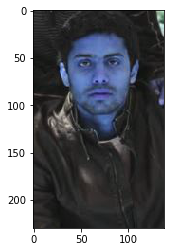

```
Tibetan_mastiff
```

```python
for file_path in my_files:
    dog_or_human(file_path)
```